# 12. Analyze Strand Origin

Will Hannon

05 October, 2023

The goal of this notebook is to analyze variants and coverage split by the strand of origin (+/- sense).

```r
## ==== File paths input data ==== ##

if (exists("snakemake")) {

  # Data from lofreq and varscan labeled with subclonal haplotypes
  updated.data = snakemake@params[["incsv"]]

  # Variants split by positive and negative strand
  split.variant.data = snakemake@input[[3]]

  # Coverage by split by positive and negative strand
  split.coverage.data = snakemake@input[[2]]

  # Annotations for the standard Measles ORFs ~ for making pretty figures.
  annotations.filepath = snakemake@params[['annotations']]

} else {

  # Data from lofreq and varscan labeled with subclonal haplotypes
  updated.data = "../../results/variants/validated_variants.csv"

  # Variants split by positive and negative strand
  split.variant.data = "../../results/split/split_read_variants.csv"

  # Coverage by split by positive and negative strand
  split.coverage.data = "../../results/split/merged.split.depth"

  # Annotations for the standard Measles ORFs ~ for making pretty figures.
  annotations.filepath = "../../config/annotations.csv"

}
```

```r
## ==== File paths output data ==== ##

if (exists("snakemake")) {

  # Path to save figures
  figure.dir = paste0(snakemake@params[['figures']], "/")

} else {

  # Path to save figures
  figure.dir = "../../results/figures/"

}

# Make the figure directory if it doesn't exist
if (!file.exists(figure.dir)) {
  dir.create(figure.dir, recursive = TRUE)
  print("Directory created.")
} else {
  print("Directory already exists.")
}
```

```
## [1] "Directory already exists."
```

## Read Coverage by Strand

First, I’ll investigate how read coverage differs by the strand of origin.

Then the coverage was determined using `samtools depth`:

```
samtools depth -m 0 -a -q {params.score} -g DUP {input.bam} > {output.coverage}
```

```r
# Import and process information about coverage/read depth
split.coverage.df = fread(split.coverage.data) %>%
  select(!V1) %>%
  mutate(Tissue = str_replace_all(Accession, "_", " "))

split.coverage.df %>%
  head()
```

```
##    POS  DP        Accession Direction           Tissue
## 1:   1 187 Frontal_Cortex_2  Negative Frontal Cortex 2
## 2:   2 192 Frontal_Cortex_2  Negative Frontal Cortex 2
## 3:   3 196 Frontal_Cortex_2  Negative Frontal Cortex 2
## 4:   4 196 Frontal_Cortex_2  Negative Frontal Cortex 2
## 5:   5 198 Frontal_Cortex_2  Negative Frontal Cortex 2
## 6:   6 203 Frontal_Cortex_2  Negative Frontal Cortex 2
```

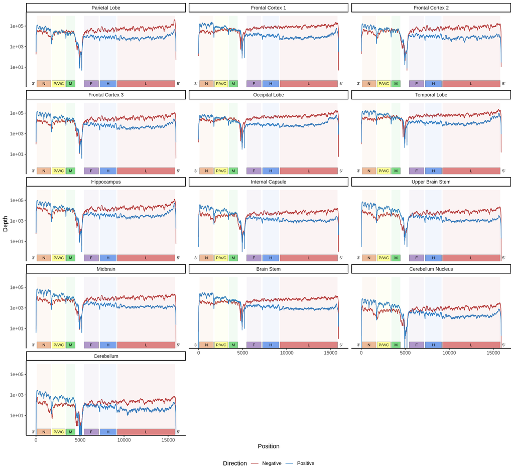

```r
split.coverage.df %>%
  mutate(Tissue = if_else(Tissue == "UBS", "Upper Brain Stem", Tissue)) %>%
  filter(!Tissue %in% c("SSPE 1", "SSPE 2")) %>%
  mutate(Tissue = factor(Tissue, levels = tissue.order)) %>%
  ggplot(aes(x = POS, y = DP, col = Direction)) +
    geom_line() +
    facet_wrap(~Tissue, ncol = 3) +
    scale_y_log10() +
    scale_color_manual(values = c("#B63F3E", "#307EC2")) +
    xlab("Position") +
    ylab("Depth") +

    # == Annotations of genes == #

    # 3' Start
    annotate(geom = "text", x = (N$Start - 400), y = .25, label = "3'", size = 2.5) +

    # Nucleoprotein
    annotate("rect", xmin = N$Start-1, xmax = N$Stop, ymin = 0, ymax = .5 ,
               alpha = .5, fill = "#d97634", col = "black", size = .1) +
    annotate(geom = "text", x = (N$Stop + N$Start)/2, y = .25, label = "N", family = "helvetica", size = 2.5) +
    annotate("rect", xmin = N$Start-1, xmax = N$Stop, ymin = .5, ymax = 1e6 ,
                   alpha = .05, fill = "#d97634", size = .1) +
    # P/V/C
    annotate("rect", xmin = P.V.C$Start, xmax = P.V.C$Stop, ymin = 0, ymax = .5 ,
               alpha = .5, fill = "#fcff3d", col = "black", size = .1) +
    annotate(geom = "text", x = (P.V.C$Stop + P.V.C$Start)/2, y = .25, label = "P/V/C", family = "helvetica", size = 2.5) +
    annotate("rect", xmin = P.V.C$Start, xmax = P.V.C$Stop, ymin = 0, ymax = 1e6 ,
               alpha = .05, fill = "#fcff3d", size = .1) +
    # Matrix protein
    annotate("rect", xmin = M$Start, xmax = M$Stop, ymin = 0, ymax = .5 ,
               alpha = .5, fill = "#0db51b", col = "black", size = .1) +
    annotate(geom = "text", x = (M$Stop + M$Start)/2, y = .25, label = "M", family = "helvetica", size = 2.5)  +
    annotate("rect", xmin = M$Start, xmax = M$Stop, ymin = 0, ymax = 1e6 ,
               alpha = .05, fill = "#0db51b", size = .1) +
    # Fusion protein
    annotate("rect", xmin = F.$Start, xmax = F.$Stop, ymin = 0, ymax = .5 ,
               alpha = .5, fill = "#6A3D9A", col = "black", size = .1) +
    annotate(geom = "text", x = (F.$Stop + F.$Start)/2, y = .25, label = "F", family = "helvetica", size = 2.5) +
    annotate("rect", xmin = F.$Start, xmax = F.$Stop, ymin = 0, ymax = 1e6 ,
               alpha = .05, fill = "#6A3D9A", size = .1) +
    # Hemagluttinin
    annotate("rect", xmin = H$Start, xmax = H$Stop, ymin = 0, ymax = .5 ,
               alpha = .5, fill = "#0251d9", col = "black", size = .1) +
    annotate(geom = "text", x = (H$Stop + H$Start)/2, y = .25, label = "H", family = "helvetica", size = 2.5) +
    annotate("rect", xmin = H$Start, xmax = H$Stop, ymin = 0, ymax = 1e6,
               alpha = .05, fill = "#0251d9", size = .1) +
    # Large protein
    annotate("rect", xmin = L$Start, xmax = L$Stop, ymin = 0, ymax = .5 ,
               alpha = .5, fill = "#bf1515", col = "black", size = .1) +
    annotate(geom = "text", x = (L$Stop + L$Start)/2, y = .25, label = "L", family = "helvetica", size = 2.5) +
    annotate("rect", xmin = L$Start, xmax = L$Stop, ymin = 0, ymax = 1e6 ,
               alpha = .05, fill = "#bf1515", size = .1) +

    # 5' Start
    annotate(geom = "text", x = (L$Stop + 400), y =  .25, label = "5'", size = 2.5) +

    theme_classic() +
    theme(legend.position = "bottom")
```

```r
ggsave(paste(figure.dir, "figure-4.tiff"), device = "tiff", width = 13, height = 12, dpi = 300)
```

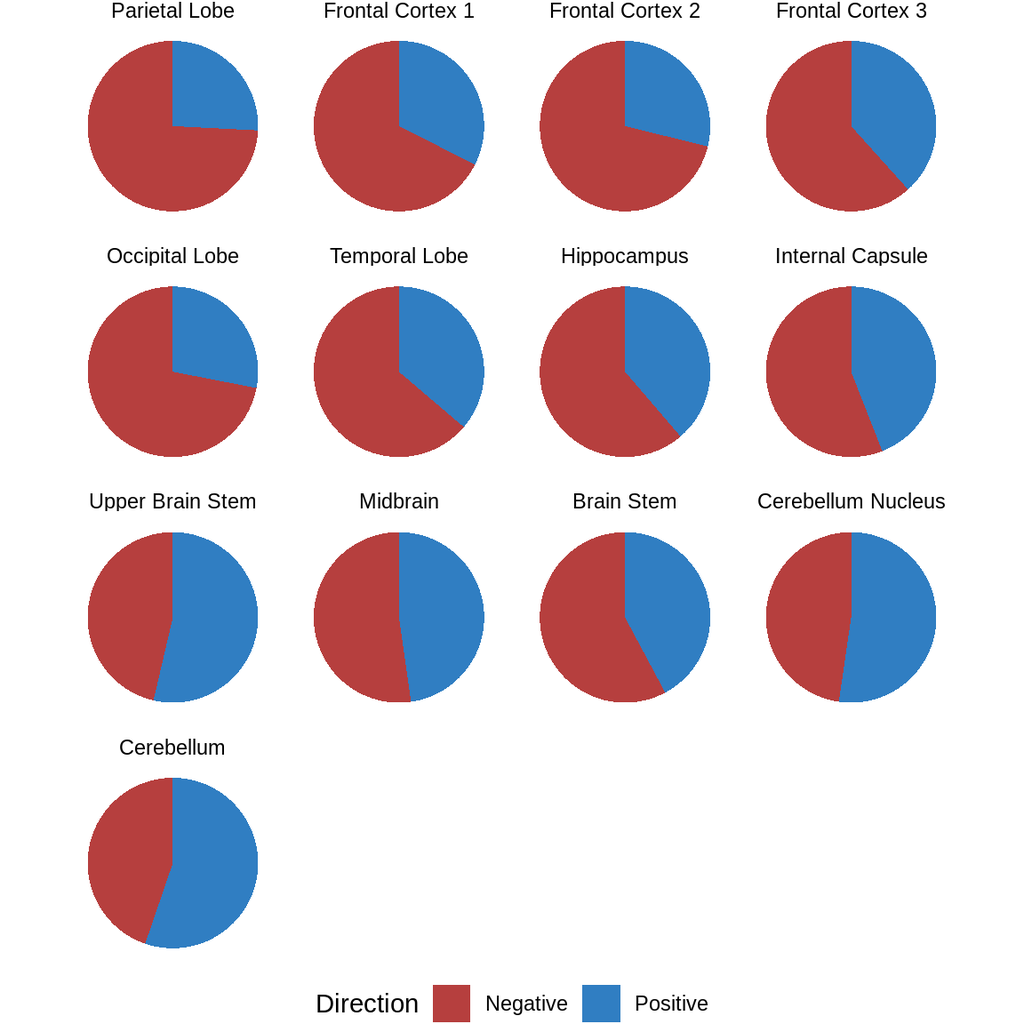

```r
# Calculate the relative coverage ration for positive and negative sense strands.
split.coverage.df %>%
  group_by(Tissue, Direction) %>%
  summarize(Mean = mean(DP)) %>%
  ungroup() %>%
  group_by(Tissue) %>%
  mutate(Frequency = Mean / sum(Mean)) %>%
  ungroup() %>%
  select(Tissue, Direction, Frequency) %>%
  mutate(Tissue = if_else(Tissue == "UBS", "Upper Brain Stem", Tissue)) %>%
  filter(!Tissue %in% c("SSPE 1", "SSPE 2")) %>%
  mutate(Tissue = factor(Tissue, levels = tissue.order)) %>%
  ggplot(aes(x = "", y = Frequency, fill = Direction)) +
    geom_bar(width = 1, stat = "identity") +
    scale_fill_manual(values = c("#B63F3E", "#307EC2")) +
    coord_polar(theta = "y") +
    facet_wrap(~Tissue) +
    theme_void() +
    theme(legend.position = "bottom")
```

```r
ggsave(paste(figure.dir, "figure-4-pies.tiff"), device = "tiff", width = 6, height = 6, dpi = 300)
```

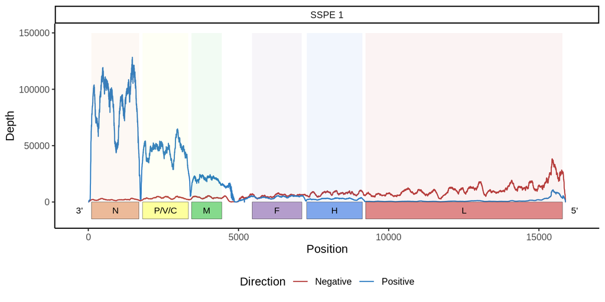

```r
split.coverage.df %>%
  filter(Tissue %in% c("SSPE 1")) %>%
  ggplot(aes(x = POS, y = DP, col = Direction)) +
    geom_line() +
    facet_wrap(~Tissue, ncol = 1) +
    scale_color_manual(values = c("#B63F3E", "#307EC2")) +
    xlab("Position") +
    ylab("Depth") +

    # == Annotations of genes == #

    # 3' Start
    annotate(geom = "text", x = (N$Start - 400), y = -15000/2, label = "3'", size = 3) +

    # Nucleoprotein
    annotate("rect", xmin = N$Start-1, xmax = N$Stop, ymin = 0, ymax = -15000 ,
               alpha = .5, fill = "#d97634", col = "black", size = .1) +
    annotate(geom = "text", x = (N$Stop + N$Start)/2, y = -15000/2, label = "N", family = "helvetica", size = 3) +
    annotate("rect", xmin = N$Start-1, xmax = N$Stop, ymin = .5, ymax = 150000 ,
                   alpha = .05, fill = "#d97634", size = .1) +
    # P/V/C
    annotate("rect", xmin = P.V.C$Start, xmax = P.V.C$Stop, ymin = 0, ymax = -15000 ,
               alpha = .5, fill = "#fcff3d", col = "black", size = .1) +
    annotate(geom = "text", x = (P.V.C$Stop + P.V.C$Start)/2, y = -15000/2, label = "P/V/C", family = "helvetica", size = 3) +
    annotate("rect", xmin = P.V.C$Start, xmax = P.V.C$Stop, ymin = 0, ymax = 150000 ,
               alpha = .05, fill = "#fcff3d", size = .1) +
    # Matrix protein
    annotate("rect", xmin = M$Start, xmax = M$Stop, ymin = 0, ymax = -15000 ,
               alpha = .5, fill = "#0db51b", col = "black", size = .1) +
    annotate(geom = "text", x = (M$Stop + M$Start)/2, y = -15000/2, label = "M", family = "helvetica", size = 3)  +
    annotate("rect", xmin = M$Start, xmax = M$Stop, ymin = 0, ymax = 150000 ,
               alpha = .05, fill = "#0db51b", size = .1) +
    # Fusion protein
    annotate("rect", xmin = F.$Start, xmax = F.$Stop, ymin = 0, ymax = -15000 ,
               alpha = .5, fill = "#6A3D9A", col = "black", size = .1) +
    annotate(geom = "text", x = (F.$Stop + F.$Start)/2, y = -15000/2, label = "F", family = "helvetica", size = 3) +
    annotate("rect", xmin = F.$Start, xmax = F.$Stop, ymin = 0, ymax = 150000 ,
               alpha = .05, fill = "#6A3D9A", size = .1) +
    # Hemagluttinin
    annotate("rect", xmin = H$Start, xmax = H$Stop, ymin = 0, ymax = -15000 ,
               alpha = .5, fill = "#0251d9", col = "black", size = .1) +
    annotate(geom = "text", x = (H$Stop + H$Start)/2, y = -15000/2, label = "H", family = "helvetica", size = 3) +
    annotate("rect", xmin = H$Start, xmax = H$Stop, ymin = 0, ymax = 150000,
               alpha = .05, fill = "#0251d9", size = .1) +
    # Large protein
    annotate("rect", xmin = L$Start, xmax = L$Stop, ymin = 0, ymax = -15000 ,
               alpha = .5, fill = "#bf1515", col = "black", size = .1) +
    annotate(geom = "text", x = (L$Stop + L$Start)/2, y = -15000/2, label = "L", family = "helvetica", size = 3) +
    annotate("rect", xmin = L$Start, xmax = L$Stop, ymin = 0, ymax = 150000 ,
               alpha = .05, fill = "#bf1515", size = .1) +

    # 5' Start
    annotate(geom = "text", x = (L$Stop + 400), y =  -15000/2, label = "5'", size = 3) +

    theme_classic()  +
    theme(legend.position = "bottom")
```

```r
ggsave(paste(figure.dir, "figure-1d.tiff"), device = "tiff", width = 8, height = 6, dpi = 300)
```

## Does strand origin change allele frequency?

It’s interesting to see that coverage differs over the genome by strand. This is consistent with the presence of genomic RNA and messenger RNA that’s subject to a gradient of transcription. Let’s also see if there is a clear difference in the frequency of alleles between strands.

We’ll use the SNPs that we’ve already validated and processed in the first notebook to subset the SNPs called for each strand. We’re really only interested to see if strand origin effects this subset of SNPs.

```r
# Read in the validated variant set called on *both* strands
validated.variants.df = read_csv(updated.data, show_col_types = F)
# Get the validated SNPs to filter the SNPs from each strand
validated.snps = validated.variants.df %>%
  mutate(ID = paste(Accession, SNP, sep = "-")) %>%
  pull(ID) %>%
  unique()

# Read in the strand-origin variants (from both varscan and lofreq)
split.variants.df = read_csv(split.variant.data, show_col_types = F) %>%
  # drop the columns we don't need
  select(!c(Virus, Host, R1, R2, Sample)) %>%
  # rename the directions to positive and negative
  mutate(
         SNP = paste0(REF, POS, ALT),
         ID = paste(Accession, SNP, sep = "-")) %>%
  # filter to get the set of validated variants
  filter(ID %in% validated.snps)
```

The main thing we’re interested in is whether the origin of the strand (positive or negative sense RNA) impacts the frequency of the SNPs.

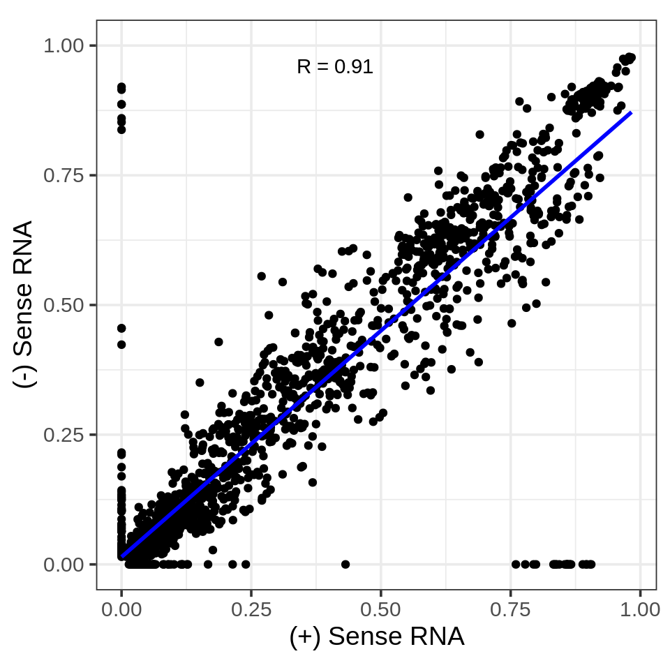

Let’s see how the contribution from each tissue plays into this:

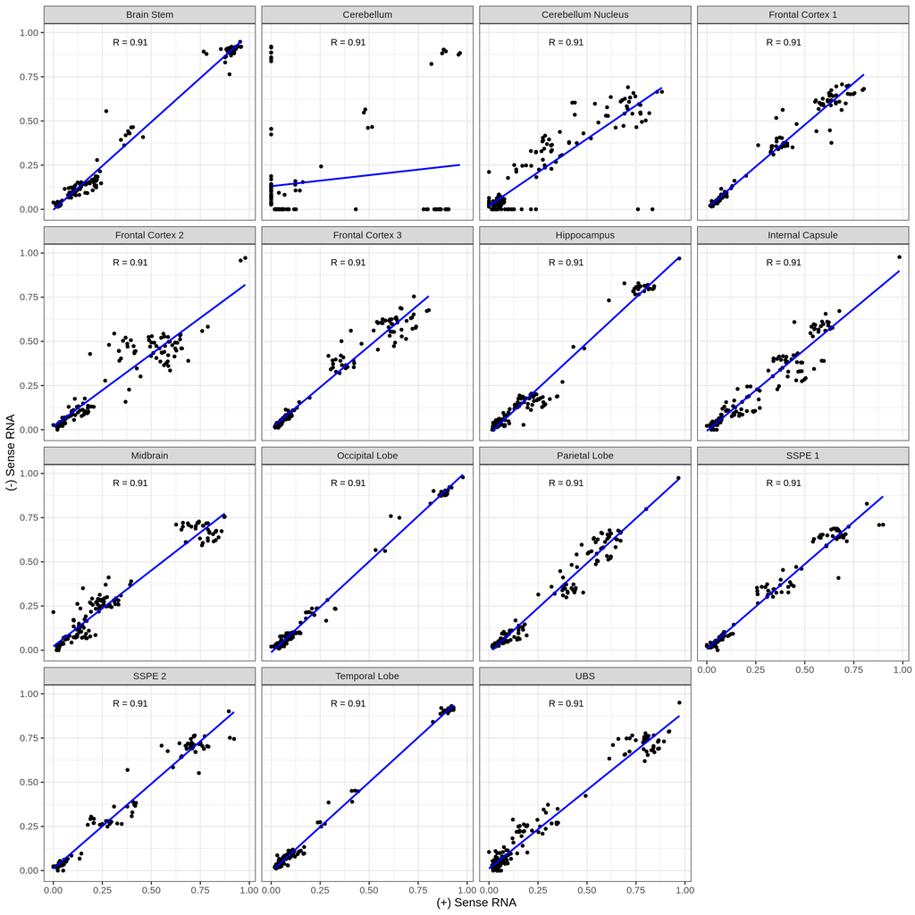

It looks like the correlation is the worst in the Cerebellum and Cerebellum Nucleus samples. This isn’t so surprising since these samples had very few reads.

One of the most likely things to impact this is how well sampled a SNP is in a given tissue. Therefore, we need to filter out `Tissue`/`SNP` pairs where the `SNP` is very low depth in that `Tissue`. Ideally, we only want to observe biological differences in allele frequency between strands, not sampling differences. Let’s see what happens when we apply a relatively stringent filter on the number of observation of variants in the validated data.

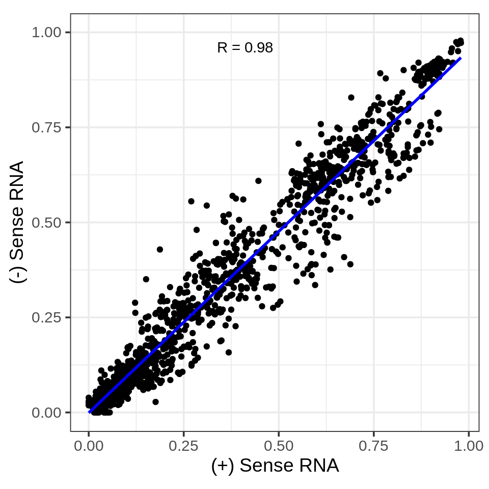